# Libraries

```python
import os
import sqlite3
from google.colab import drive
import warnings
warnings.filterwarnings("ignore")

import numpy as np
import pandas as pd
import matplotlib.pyplot as plt
import seaborn as sns

from IPython.display import display, Markdown
```

```python
# Plot style
plt.rcParams["figure.figsize"] = (12, 5)
plt.rcParams["axes.titlesize"] = 13
plt.rcParams["axes.labelsize"] = 11
sns.set_theme(style="whitegrid")

pd.set_option("display.max_columns", 200)
pd.set_option("display.float_format", lambda x: f"{x:,.2f}")
```

# Data Loading

```python
drive.mount('drive')
db_path = 'drive/MyDrive/Grab/grab_vn_case.db'
```

```
Mounted at drive
```

```python
# Check file exists first
if not os.path.exists(db_path):
    raise FileNotFoundError(f"Database not found: {db_path}")

conn = sqlite3.connect(db_path)
cur = conn.cursor()

try:
    # Optional: check available tables
    cur.execute("SELECT name FROM sqlite_master WHERE type='table';")
    print("Tables:", cur.fetchall())

    cur.execute("SELECT * FROM transactions LIMIT 3;")
    transactions_rows = cur.fetchall()

    cur.execute("SELECT * FROM users LIMIT 3;")
    users_rows = cur.fetchall()

    cur.execute("SELECT * FROM weather_daily LIMIT 3;")
    weather_rows = cur.fetchall()

    print("transactions:", transactions_rows)
    print("users:", users_rows)
    print("weather_daily:", weather_rows)

finally:
    cur.close()
    conn.close()
```

```
Tables: [('users',), ('weather_daily',), ('transactions',)]
transactions: [(1, '2024-01-01', 1, 'Pre-Promo', 'Ho Chi Minh City', 'GrabBike', 2883, 'Card', 35.53, 0.0, 35.53, 0, 1.6), (2, '2024-01-01', 1, 'Pre-Promo', 'Ho Chi Minh City', 'GrabBike', 5904, 'Cash', 36.74, 0.0, 36.74, 0, 1.6), (3, '2024-01-01', 1, 'Pre-Promo', 'Ho Chi Minh City', 'GrabBike', 119…
users: [(1, 'Ho Chi Minh City', 'Cash', 'Regular', '2023-08-18'), (2, 'Ho Chi Minh City', 'ZaloPay', 'High Value', '2023-08-03'), (3, 'Ho Chi Minh City', 'Cash', 'Voucher Hunter', '2023-09-06')]
weather_daily: [('2024-01-01', 'Ho Chi Minh City', 1.6, 'None'), ('2024-01-01', 'Da Nang', 5.3, 'Light'), ('2024-01-01', 'Hanoi', 1.7, 'None')]
```

Loaded the SQLite database and verified the file path is valid. Checked the available tables and previewed a few rows from the core tables (`transactions`, `users`, `weather_daily`) to confirm the schema and data were loaded correctly before analysis.

```python
# Re-establish connection and cursor as they were closed in the previous cell
conn = sqlite3.connect(db_path)
cur = conn.cursor()

# transactions
cur.execute("SELECT * FROM transactions LIMIT 10;")
transactions = cur.fetchall()
print("transactions:")
print(transactions)

# users
cur.execute("SELECT * FROM users LIMIT 10;")
users = cur.fetchall()
print("users:")
print(users)

# weather_daily
cur.execute("SELECT * FROM weather_daily LIMIT 10;")
weather_daily = cur.fetchall()
print("weather_daily:")
print(weather_daily)

cur.close()
conn.close()
```

```
transactions:
[(1, '2024-01-01', 1, 'Pre-Promo', 'Ho Chi Minh City', 'GrabBike', 2883, 'Card', 35.53, 0.0, 35.53, 0, 1.6), (2, '2024-01-01', 1, 'Pre-Promo', 'Ho Chi Minh City', 'GrabBike', 5904, 'Cash', 36.74, 0.0, 36.74, 0, 1.6), (3, '2024-01-01', 1, 'Pre-Promo', 'Ho Chi Minh City', 'GrabBike', 1193, 'Cash', 44.…
users:
[(1, 'Ho Chi Minh City', 'Cash', 'Regular', '2023-08-18'), (2, 'Ho Chi Minh City', 'ZaloPay', 'High Value', '2023-08-03'), (3, 'Ho Chi Minh City', 'Cash', 'Voucher Hunter', '2023-09-06'), (4, 'Ho Chi Minh City', 'Cash', 'Voucher Hunter', '2023-07-25'), (5, 'Ho Chi Minh City', 'Cash', 'Regular', '202…
weather_daily:
[('2024-01-01', 'Ho Chi Minh City', 1.6, 'None'), ('2024-01-01', 'Da Nang', 5.3, 'Light'), ('2024-01-01', 'Hanoi', 1.7, 'None'), ('2024-01-02', 'Ho Chi Minh City', 1.8, 'None'), ('2024-01-02', 'Da Nang', 5.3, 'Light'), ('2024-01-02', 'Hanoi', 2.4, 'Light'), ('2024-01-03', 'Ho Chi Minh City', 2.0, 'N…
```

Queried sample rows from the main tables to verify data structure and familiarize with the contents before proceeding with the analysis.

```python
# Re-establish the database connection
conn = sqlite3.connect(db_path)

# Load each table into a pandas DataFrame
df_transactions = pd.read_sql_query("SELECT * FROM transactions;", conn)  # Transaction-level data
df_users = pd.read_sql_query("SELECT * FROM users;", conn)  # User information
df_weather_daily = pd.read_sql_query("SELECT * FROM weather_daily;", conn)  # Daily weather data

# Load an additional view for quick trend analysis
df_daily_gmv = pd.read_sql_query("SELECT * FROM daily_gmv_summary;", conn)  # Aggregated GMV by day

# Close the database connection after loading data
conn.close()
```

```python
df_transactions.head()
```

|  | transaction_id | date | week_number | period | city | service_type | user_id | payment_type | gross_gmv_k_vnd | discount_k_vnd | net_gmv_k_vnd | voucher_applied | rainfall_mm |
| --- | --- | --- | --- | --- | --- | --- | --- | --- | --- | --- | --- | --- | --- |
| 0 | 1 | 2024-01-01 | 1 | Pre-Promo | Ho Chi Minh City | GrabBike | 2883 | Card | 35.53 | 0.00 | 35.53 | 0 | 1.60 |
| 1 | 2 | 2024-01-01 | 1 | Pre-Promo | Ho Chi Minh City | GrabBike | 5904 | Cash | 36.74 | 0.00 | 36.74 | 0 | 1.60 |
| 2 | 3 | 2024-01-01 | 1 | Pre-Promo | Ho Chi Minh City | GrabBike | 1193 | Cash | 44.65 | 0.00 | 44.65 | 0 | 1.60 |
| 3 | 4 | 2024-01-01 | 1 | Pre-Promo | Ho Chi Minh City | GrabBike | 3622 | ZaloPay | 38.32 | 0.00 | 38.32 | 0 | 1.60 |
| 4 | 5 | 2024-01-01 | 1 | Pre-Promo | Ho Chi Minh City | GrabBike | 5869 | Cash | 28.52 | 0.00 | 28.52 | 0 | 1.60 |

```python
df_users.head()
```

|  | user_id | city | payment_preference | user_segment | registration_date |
| --- | --- | --- | --- | --- | --- |
| 0 | 1 | Ho Chi Minh City | Cash | Regular | 2023-08-18 |
| 1 | 2 | Ho Chi Minh City | ZaloPay | High Value | 2023-08-03 |
| 2 | 3 | Ho Chi Minh City | Cash | Voucher Hunter | 2023-09-06 |
| 3 | 4 | Ho Chi Minh City | Cash | Voucher Hunter | 2023-07-25 |
| 4 | 5 | Ho Chi Minh City | Cash | Regular | 2022-07-29 |

```python
df_weather_daily.head()
```

|  | date | city | rainfall_mm | rain_category |
| --- | --- | --- | --- | --- |
| 0 | 2024-01-01 | Ho Chi Minh City | 1.60 | None |
| 1 | 2024-01-01 | Da Nang | 5.30 | Light |
| 2 | 2024-01-01 | Hanoi | 1.70 | None |
| 3 | 2024-01-02 | Ho Chi Minh City | 1.80 | None |
| 4 | 2024-01-02 | Da Nang | 5.30 | Light |

```python
df_daily_gmv.head()
```

|  | date | week_number | period | city | service_type | payment_type | net_gmv_k_vnd | gross_gmv_k_vnd | total_discount_k_vnd | n_transactions | n_voucher_redemptions |
| --- | --- | --- | --- | --- | --- | --- | --- | --- | --- | --- | --- |
| 0 | 2024-01-01 | 1 | Pre-Promo | Da Nang | GrabBike | Card | 332.00 | 332.00 | 0.00 | 9 | 0 |
| 1 | 2024-01-01 | 1 | Pre-Promo | Da Nang | GrabBike | Cash | 1,832.92 | 1,832.92 | 0.00 | 51 | 0 |
| 2 | 2024-01-01 | 1 | Pre-Promo | Da Nang | GrabBike | ZaloPay | 632.41 | 632.41 | 0.00 | 17 | 0 |
| 3 | 2024-01-01 | 1 | Pre-Promo | Da Nang | GrabCar | Card | 152.75 | 152.75 | 0.00 | 1 | 0 |
| 4 | 2024-01-01 | 1 | Pre-Promo | Da Nang | GrabCar | Cash | 1,895.53 | 1,895.53 | 0.00 | 14 | 0 |

# Exploratory Data Analysis

## Data Overview

```python
print("users:", df_users.shape)
print("weather_daily:", df_weather_daily.shape)
print("transactions:", df_transactions.shape)
print("daily_gmv_summary:", df_daily_gmv.shape)
```

```
users: (11800, 5)
weather_daily: (294, 4)
transactions: (182313, 13)
daily_gmv_summary: (2642, 11)
```

```python
print("users:", df_users.columns)
print("weather_daily:", df_weather_daily.columns)
print("transactions:", df_transactions.columns)
print("daily_gmv_summary:", df_daily_gmv.columns)
```

```
users: Index(['user_id', 'city', 'payment_preference', 'user_segment',
       'registration_date'],
      dtype='object')
weather_daily: Index(['date', 'city', 'rainfall_mm', 'rain_category'], dtype='object')
transactions: Index(['transaction_id', 'date', 'week_number', 'period', 'city',
       'service_type', 'user_id', 'payment_type', 'gross_gmv_k_vnd',
       'discount_k_vnd', 'net_gmv_k_vnd', 'voucher_applied', 'rainfall_mm'],
      dtype='object')
daily_gmv_summary: Index(['date', 'week_number', 'period', 'city', 'service_type', 'payment_type',
       'net_gmv_k_vnd', 'gross_gmv_k_vnd', 'total_discount_k_vnd',
       'n_transactions', 'n_voucher_redemptions'],
      dtype='object')
```

```python
print("users:", df_users.info())
print("weather_daily:", df_weather_daily.info())
print("transactions:", df_transactions.info())
print("daily_gmv_summary:", df_daily_gmv.info())
```

```
<class 'pandas.core.frame.DataFrame'>
RangeIndex: 11800 entries, 0 to 11799
Data columns (total 5 columns):
 #   Column              Non-Null Count  Dtype
---  ------              --------------  -----
 0   user_id             11800 non-null  int64
 1   city                11800 non-null  object
 2   payment_preference  11800 non-null  object
 3   user_segment        11800 non-null  object
 4   registration_date   11800 non-null  object
dtypes: int64(1), object(4)
memory usage: 461.1+ KB
users: None
<class 'pandas.core.frame.DataFrame'>
RangeIndex: 294 entries, 0 to 293
Data columns (total 4 columns):
 #   Column         Non-Null Count  Dtype
---  ------         --------------  -----
 0   date           294 non-null    object
 1   city           294 non-null    object
 2   rainfall_mm    294 non-null    float64
 3   rain_category  294 non-null    object
dtypes: float64(1), object(3)
memory usage: 9.3+ KB
weather_daily: None
<class 'pandas.core.frame.DataFrame'>
RangeIndex: 182313 entries, 0 to 182312
Data columns (total 13 columns):
 #   Column           Non-Null Count   Dtype
---  ------           --------------   -----
 0   transaction_id   182313 non-null  int64
 1   date             182313 non-null  object
 2   week_number      182313 non-null  int64
 3   period           182313 non-null  object
 4   city             182313 non-null  object
 5   service_type     182313 non-null  object
 6   user_id          182313 non-null  int64
 7   payment_type     182313 non-null  object
 8   gross_gmv_k_vnd  182313 non-null  float64
 9   discount_k_vnd   182313 non-null  float64
```

[output cut: 10 more lines]

```
---  ------                 --------------  -----
 0   date                   2642 non-null   object
 1   week_number            2642 non-null   int64
 2   period                 2642 non-null   object
 3   city                   2642 non-null   object
 4   service_type           2642 non-null   object
 5   payment_type           2642 non-null   object
 6   net_gmv_k_vnd          2642 non-null   float64
 7   gross_gmv_k_vnd        2642 non-null   float64
 8   total_discount_k_vnd   2642 non-null   float64
 9   n_transactions         2642 non-null   int64
 10  n_voucher_redemptions  2642 non-null   int64
dtypes: float64(3), int64(3), object(5)
memory usage: 227.2+ KB
daily_gmv_summary: None
```

```python
print("users:", df_users.describe())
print("weather_daily:", df_weather_daily.describe())
print("transactions:", df_transactions.describe())
print("daily_gmv_summary:", df_daily_gmv.describe())
```

```
users:         user_id
count 11,800.00
mean   5,900.50
std    3,406.51
min        1.00
25%    2,950.75
50%    5,900.50
75%    8,850.25
max   11,800.00
weather_daily:        rainfall_mm
count       294.00
mean         19.09
std          29.58
min           0.00
25%           1.82
50%           4.85
75%          23.88
max         159.20
transactions:        transaction_id  week_number    user_id  gross_gmv_k_vnd  \
count      182,313.00   182,313.00 182,313.00       182,313.00
mean        91,157.00         7.68   5,630.91           120.63
std         52,629.37         3.88   3,384.61            63.87
min              1.00         1.00       1.00            28.00
25%         45,579.00         4.00   2,724.00            42.29
50%         91,157.00         8.00   5,416.00           131.38
75%        136,735.00        11.00   8,528.00           172.54
max        182,313.00        14.00  11,800.00           225.00

       discount_k_vnd  net_gmv_k_vnd  voucher_applied  rainfall_mm
count      182,313.00     182,313.00       182,313.00   182,313.00
mean             6.43         114.20             0.19        25.33
std             15.00          60.98             0.39        34.94
min              0.00          22.96             0.00         0.00
25%              0.00          41.73             0.00         2.00
50%              0.00         123.27             0.00         6.00
75%              0.00         160.30             0.00        45.90
max             56.24         225.00             1.00       159.20
daily_gmv_summary:        week_number  net_gmv_k_vnd  gross_gmv_k_vnd  total_discount_k_vnd  \
count     2,642.00       2,642.00         2,642.00              2,642.00
mean          7.50       7,880.21         8,324.17                443.96
std           4.03      12,097.10        14,143.80              2,556.49
min           1.00         103.43           103.43                  0.00
25%           4.00       1,707.20         1,724.07                  0.00
50%           8.00       3,383.03         3,389.48                  0.00
75%          11.00       9,830.24         9,830.24                  0.00
max          14.00      98,413.85       124,440.68             26,026.79

       n_transactions  n_voucher_redemptions
count        2,642.00               2,642.00
mean            69.01                  13.25
std             85.41                  63.91
min              1.00                   0.00
25%             19.00                   0.00
50%             44.00                   0.00
75%             90.00                   0.00
max            751.00                 629.00
```

## Data Quality Check

```python
print("users:", df_users.isna().sum())
print("weather_daily:", df_weather_daily.isna().sum())
print("transactions:", df_transactions.isna().sum())
print("daily_gmv_summary:", df_daily_gmv.isna().sum())
```

```
users: user_id               0
city                  0
payment_preference    0
user_segment          0
registration_date     0
dtype: int64
weather_daily: date             0
city             0
rainfall_mm      0
rain_category    0
dtype: int64
transactions: transaction_id     0
date               0
week_number        0
period             0
city               0
service_type       0
user_id            0
payment_type       0
gross_gmv_k_vnd    0
discount_k_vnd     0
net_gmv_k_vnd      0
voucher_applied    0
rainfall_mm        0
dtype: int64
daily_gmv_summary: date                     0
week_number              0
period                   0
city                     0
service_type             0
payment_type             0
net_gmv_k_vnd            0
gross_gmv_k_vnd          0
total_discount_k_vnd     0
n_transactions           0
n_voucher_redemptions    0
dtype: int64
```

```python
print("users:", df_users.duplicated().sum())
print("weather_daily:", df_weather_daily.duplicated().sum())
print("transactions:", df_transactions.duplicated().sum())
print("daily_gmv_summary:", df_daily_gmv.duplicated().sum())
```

```
users: 0
weather_daily: 0
transactions: 0
daily_gmv_summary: 0
```

```python
for col in ["city", "payment_preference", "user_segment"]:
    print(f"\nusers - {col}")
    print(df_users[col].value_counts(dropna=False))

for col in ["city", "rain_category"]:
    print(f"\nweather_daily - {col}")
    print(df_weather_daily[col].value_counts(dropna=False))

for col in ["period", "city", "service_type", "payment_type", "voucher_applied"]:
    print(f"\ntransactions - {col}")
    print(df_transactions[col].value_counts(dropna=False))

for col in ["period", "city", "service_type", "payment_type"]:
    print(f"\ndaily_gmv_summary - {col}")
    print(df_daily_gmv[col].value_counts(dropna=False))
```

```
users - city
city
Ho Chi Minh City    6000
Hanoi               4000
Da Nang             1800
Name: count, dtype: int64

users - payment_preference
payment_preference
Cash       6369
ZaloPay    3419
Card       2012
Name: count, dtype: int64

users - user_segment
user_segment
Regular           3773
Occasional        3068
Voucher Hunter    2922
High Value        2037
Name: count, dtype: int64

weather_daily - city
city
Ho Chi Minh City    98
Hanoi               98
Da Nang             98
Name: count, dtype: int64

weather_daily - rain_category
rain_category
Light       106
None         93
Heavy        61
Moderate     34
Name: count, dtype: int64

transactions - period
period
Promo         90516
```

[output cut: 43 more lines]

```
Name: count, dtype: int64

daily_gmv_summary - service_type
service_type
GrabBike    882
GrabFood    882
GrabCar     878
Name: count, dtype: int64

daily_gmv_summary - payment_type
payment_type
Cash       882
ZaloPay    882
Card       878
Name: count, dtype: int64
```

The dataset is sufficiently clean and internally consistent for business analysis, with no major data quality issues that would block interpretation.

## Data Preprocessing

Standardized data types and categorical variables across the main tables by converting date fields to datetime format, filling missing values in `rain_category`, and defining consistent category orders for key analytical dimensions such as period, city, service type, payment type, user segment, and rainfall level.

```python
# Convert date
df_users["registration_date"] = pd.to_datetime(df_users["registration_date"])
df_weather_daily["date"] = pd.to_datetime(df_weather_daily["date"])
df_transactions["date"] = pd.to_datetime(df_transactions["date"])
df_daily_gmv["date"] = pd.to_datetime(df_daily_gmv["date"])

# Fill possible missing rain_category
df_weather_daily["rain_category"] = df_weather_daily["rain_category"].fillna("None")

# Ordered categories
period_order = ["Pre-Promo", "Promo", "Post-Promo"]
city_order = ["Ho Chi Minh City", "Hanoi", "Da Nang"]
service_order = ["GrabBike", "GrabCar", "GrabFood"]
payment_order = ["Cash", "Card", "ZaloPay"]
segment_order = ["Voucher Hunter", "Occasional", "Regular", "High Value"]
rain_order = ["None", "Light", "Moderate", "Heavy"]

for df in [df_transactions, df_daily_gmv]:
    if "period" in df.columns:
        df["period"] = pd.Categorical(df["period"], categories=period_order, ordered=True)
    if "city" in df.columns:
        df["city"] = pd.Categorical(df["city"], categories=city_order, ordered=True)

df_users["city"] = pd.Categorical(df_users["city"], categories=city_order, ordered=True)
df_users["payment_preference"] = pd.Categorical(df_users["payment_preference"], categories=payment_order, ordered=True)
df_users["user_segment"] = pd.Categorical(df_users["user_segment"], categories=segment_order, ordered=True)

df_weather_daily["city"] = pd.Categorical(df_weather_daily["city"], categories=city_order, ordered=True)
df_weather_daily["rain_category"] = pd.Categorical(df_weather_daily["rain_category"], categories=rain_order, ordered=True)

df_transactions["service_type"] = pd.Categorical(df_transactions["service_type"], categories=service_order, ordered=True)
df_transactions["payment_type"] = pd.Categorical(df_transactions["payment_type"], categories=payment_order, ordered=True)

df_daily_gmv["service_type"] = pd.Categorical(df_daily_gmv["service_type"], categories=service_order, ordered=True)
df_daily_gmv["payment_type"] = pd.Categorical(df_daily_gmv["payment_type"], categories=payment_order, ordered=True)
```

## Utility Functions

This section defines reusable utilities to keep the analysis concise and consistent; it does not contain business findings by itself.

```python
def overview(df, name):
    print("=" * 100)
    print(f"{name} | shape = {df.shape}")
    print("-" * 100)
    display(df.head())
    print("-" * 100)
    print("dtypes:")
    display(df.dtypes.to_frame("dtype"))
    print("-" * 100)
    print("missing values:")
    display(df.isna().sum().to_frame("missing"))
    print("-" * 100)
    print("duplicate rows:", df.duplicated().sum())

def numeric_summary(df, name):
    num_cols = df.select_dtypes(include=np.number).columns.tolist()
    if num_cols:
        print(f"\nNumeric summary: {name}")
        display(df[num_cols].describe().T)

def cat_summary(df, cols, top_n=10):
    for col in cols:
        print(f"\nValue counts: {col}")
        display(df[col].value_counts(dropna=False).head(top_n).to_frame("count"))

def plot_count(df, col, title, rotate=0):
    plt.figure(figsize=(8,4))
    sns.countplot(data=df, x=col, order=df[col].value_counts().index)
    plt.title(title)
    plt.xticks(rotation=rotate)
    plt.show()

def plot_bar(data, x, y, title, hue=None, rotate=0):
    plt.figure(figsize=(12,5))
    sns.barplot(data=data, x=x, y=y, hue=hue)
    plt.title(title)
    plt.xticks(rotation=rotate)
    plt.show()

def plot_line(data, x, y, title, hue=None, marker=True):
    plt.figure(figsize=(14,5))
    sns.lineplot(data=data, x=x, y=y, hue=hue, marker="o" if marker else None)
    plt.title(title)
    plt.xticks(rotation=45)
    plt.show()

def add_ratio_cols(df):
    df = df.copy()
    if {"discount_k_vnd", "gross_gmv_k_vnd"}.issubset(df.columns):
        df["discount_rate"] = np.where(df["gross_gmv_k_vnd"] > 0,
                                       df["discount_k_vnd"] / df["gross_gmv_k_vnd"], np.nan)
    if {"net_gmv_k_vnd", "gross_gmv_k_vnd"}.issubset(df.columns):
        df["net_to_gross_ratio"] = np.where(df["gross_gmv_k_vnd"] > 0,
                                            df["net_gmv_k_vnd"] / df["gross_gmv_k_vnd"], np.nan)
    return df
```

## Tables

### user table

```python
overview(df_users, "users")
numeric_summary(df_users, "users")
cat_summary(df_users, ["city", "payment_preference", "user_segment"])
```

```
====================================================================================================
users | shape = (11800, 5)
----------------------------------------------------------------------------------------------------
```

|  | user_id | city | payment_preference | user_segment | registration_date |
| --- | --- | --- | --- | --- | --- |
| 0 | 1 | Ho Chi Minh City | Cash | Regular | 2023-08-18 |
| 1 | 2 | Ho Chi Minh City | ZaloPay | High Value | 2023-08-03 |
| 2 | 3 | Ho Chi Minh City | Cash | Voucher Hunter | 2023-09-06 |
| 3 | 4 | Ho Chi Minh City | Cash | Voucher Hunter | 2023-07-25 |
| 4 | 5 | Ho Chi Minh City | Cash | Regular | 2022-07-29 |

```
----------------------------------------------------------------------------------------------------
dtypes:
```

|  | dtype |
| --- | --- |
| user_id | int64 |
| city | category |
| payment_preference | category |
| user_segment | category |
| registration_date | datetime64[ns] |

```
----------------------------------------------------------------------------------------------------
missing values:
```

|  | missing |
| --- | --- |
| user_id | 0 |
| city | 0 |
| payment_preference | 0 |
| user_segment | 0 |
| registration_date | 0 |

```
----------------------------------------------------------------------------------------------------
duplicate rows: 0

Numeric summary: users
```

|  | count | mean | std | min | 25% | 50% | 75% | max |
| --- | --- | --- | --- | --- | --- | --- | --- | --- |
| user_id | 11,800.00 | 5,900.50 | 3,406.51 | 1.00 | 2,950.75 | 5,900.50 | 8,850.25 | 11,800.00 |

```
Value counts: city
```

| city | count |
| --- | --- |
| Ho Chi Minh City | 6000 |
| Hanoi | 4000 |
| Da Nang | 1800 |

```
Value counts: payment_preference
```

| payment_preference | count |
| --- | --- |
| Cash | 6369 |
| ZaloPay | 3419 |
| Card | 2012 |

```
Value counts: user_segment
```

| user_segment | count |
| --- | --- |
| Regular | 3773 |
| Occasional | 3068 |
| Voucher Hunter | 2922 |
| High Value | 2037 |

### weather_daily table

```python
overview(df_weather_daily, "weather_daily")
numeric_summary(df_weather_daily, "weather_daily")
cat_summary(df_weather_daily, ["city", "rain_category"])
```

```
====================================================================================================
weather_daily | shape = (294, 4)
----------------------------------------------------------------------------------------------------
```

|  | date | city | rainfall_mm | rain_category |
| --- | --- | --- | --- | --- |
| 0 | 2024-01-01 | Ho Chi Minh City | 1.60 | None |
| 1 | 2024-01-01 | Da Nang | 5.30 | Light |
| 2 | 2024-01-01 | Hanoi | 1.70 | None |
| 3 | 2024-01-02 | Ho Chi Minh City | 1.80 | None |
| 4 | 2024-01-02 | Da Nang | 5.30 | Light |

```
----------------------------------------------------------------------------------------------------
dtypes:
```

|  | dtype |
| --- | --- |
| date | datetime64[ns] |
| city | category |
| rainfall_mm | float64 |
| rain_category | category |

```
----------------------------------------------------------------------------------------------------
missing values:
```

|  | missing |
| --- | --- |
| date | 0 |
| city | 0 |
| rainfall_mm | 0 |
| rain_category | 0 |

```
----------------------------------------------------------------------------------------------------
duplicate rows: 0

Numeric summary: weather_daily
```

|  | count | mean | std | min | 25% | 50% | 75% | max |
| --- | --- | --- | --- | --- | --- | --- | --- | --- |
| rainfall_mm | 294.00 | 19.09 | 29.58 | 0.00 | 1.82 | 4.85 | 23.88 | 159.20 |

```
Value counts: city
```

| city | count |
| --- | --- |
| Ho Chi Minh City | 98 |
| Hanoi | 98 |
| Da Nang | 98 |

```
Value counts: rain_category
```

| rain_category | count |
| --- | --- |
| Light | 106 |
| None | 93 |
| Heavy | 61 |
| Moderate | 34 |

### transactions table

```python
overview(df_transactions, "transactions")
numeric_summary(df_transactions, "transactions")
cat_summary(df_transactions, ["period", "city", "service_type", "payment_type", "voucher_applied"])
```

```
====================================================================================================
transactions | shape = (182313, 13)
----------------------------------------------------------------------------------------------------
```

|  | transaction_id | date | week_number | period | city | service_type | user_id | payment_type | gross_gmv_k_vnd | discount_k_vnd | net_gmv_k_vnd | voucher_applied | rainfall_mm |
| --- | --- | --- | --- | --- | --- | --- | --- | --- | --- | --- | --- | --- | --- |
| 0 | 1 | 2024-01-01 | 1 | Pre-Promo | Ho Chi Minh City | GrabBike | 2883 | Card | 35.53 | 0.00 | 35.53 | 0 | 1.60 |
| 1 | 2 | 2024-01-01 | 1 | Pre-Promo | Ho Chi Minh City | GrabBike | 5904 | Cash | 36.74 | 0.00 | 36.74 | 0 | 1.60 |
| 2 | 3 | 2024-01-01 | 1 | Pre-Promo | Ho Chi Minh City | GrabBike | 1193 | Cash | 44.65 | 0.00 | 44.65 | 0 | 1.60 |
| 3 | 4 | 2024-01-01 | 1 | Pre-Promo | Ho Chi Minh City | GrabBike | 3622 | ZaloPay | 38.32 | 0.00 | 38.32 | 0 | 1.60 |
| 4 | 5 | 2024-01-01 | 1 | Pre-Promo | Ho Chi Minh City | GrabBike | 5869 | Cash | 28.52 | 0.00 | 28.52 | 0 | 1.60 |

```
----------------------------------------------------------------------------------------------------
dtypes:
```

|  | dtype |
| --- | --- |
| transaction_id | int64 |
| date | datetime64[ns] |
| week_number | int64 |
| period | category |
| city | category |
| service_type | category |
| user_id | int64 |
| payment_type | category |
| gross_gmv_k_vnd | float64 |
| discount_k_vnd | float64 |
| net_gmv_k_vnd | float64 |
| voucher_applied | int64 |
| rainfall_mm | float64 |

```
----------------------------------------------------------------------------------------------------
missing values:
```

|  | missing |
| --- | --- |
| transaction_id | 0 |
| date | 0 |
| week_number | 0 |
| period | 0 |
| city | 0 |
| service_type | 0 |
| user_id | 0 |
| payment_type | 0 |
| gross_gmv_k_vnd | 0 |
| discount_k_vnd | 0 |
| net_gmv_k_vnd | 0 |
| voucher_applied | 0 |
| rainfall_mm | 0 |

```
----------------------------------------------------------------------------------------------------
duplicate rows: 0

Numeric summary: transactions
```

|  | count | mean | std | min | 25% | 50% | 75% | max |
| --- | --- | --- | --- | --- | --- | --- | --- | --- |
| transaction_id | 182,313.00 | 91,157.00 | 52,629.37 | 1.00 | 45,579.00 | 91,157.00 | 136,735.00 | 182,313.00 |
| week_number | 182,313.00 | 7.68 | 3.88 | 1.00 | 4.00 | 8.00 | 11.00 | 14.00 |
| user_id | 182,313.00 | 5,630.91 | 3,384.61 | 1.00 | 2,724.00 | 5,416.00 | 8,528.00 | 11,800.00 |
| gross_gmv_k_vnd | 182,313.00 | 120.63 | 63.87 | 28.00 | 42.29 | 131.38 | 172.54 | 225.00 |
| discount_k_vnd | 182,313.00 | 6.43 | 15.00 | 0.00 | 0.00 | 0.00 | 0.00 | 56.24 |
| net_gmv_k_vnd | 182,313.00 | 114.20 | 60.98 | 22.96 | 41.73 | 123.27 | 160.30 | 225.00 |
| voucher_applied | 182,313.00 | 0.19 | 0.39 | 0.00 | 0.00 | 0.00 | 0.00 | 1.00 |
| rainfall_mm | 182,313.00 | 25.33 | 34.94 | 0.00 | 2.00 | 6.00 | 45.90 | 159.20 |

```
Value counts: period
```

| period | count |
| --- | --- |
| Promo | 90516 |
| Pre-Promo | 69710 |
| Post-Promo | 22087 |

```
Value counts: city
```

| city | count |
| --- | --- |
| Ho Chi Minh City | 101190 |
| Hanoi | 55860 |
| Da Nang | 25263 |

```
Value counts: service_type
```

| service_type | count |
| --- | --- |
| GrabFood | 104541 |
| GrabBike | 57556 |
| GrabCar | 20216 |

```
Value counts: payment_type
```

| payment_type | count |
| --- | --- |
| Cash | 103434 |
| ZaloPay | 49640 |
| Card | 29239 |

```
Value counts: voucher_applied
```

| voucher_applied | count |
| --- | --- |
| 0 | 147298 |
| 1 | 35015 |

These tables provide a complete structure to analyze user baseline, transactional performance, and external factors affecting promo outcomes.

## City Baseline Overview

### User and Market Structure

|  | city | n_users |
| --- | --- | --- |
| 0 | Ho Chi Minh City | 6000 |
| 1 | Hanoi | 4000 |
| 2 | Da Nang | 1800 |

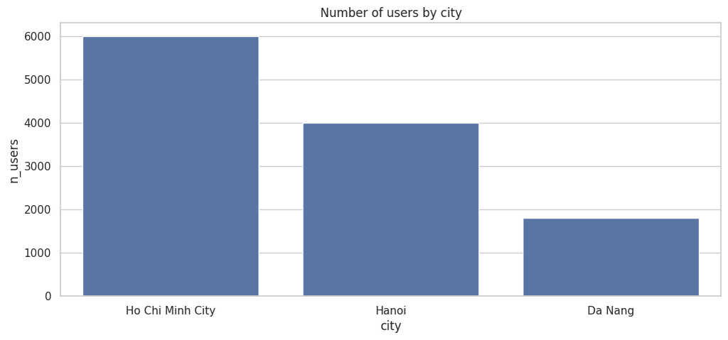

```python
# Num of users by city
users_by_city = df_users.groupby("city", observed=False)["user_id"].nunique().reset_index(name="n_users")
display(users_by_city)

plot_bar(users_by_city, x="city", y="n_users", title="Number of users by city")
```

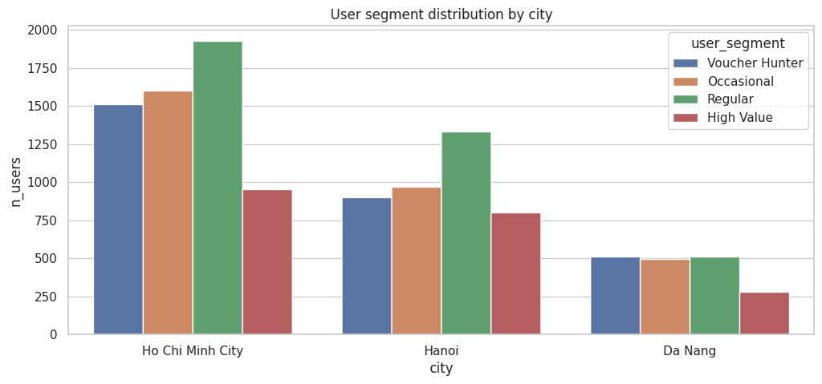

```python
# User segment by city
users_seg_city = (
    df_users.groupby(["city", "user_segment"], observed=False)["user_id"]
    .nunique()
    .reset_index(name="n_users")
)

plt.figure(figsize=(12,5))
sns.barplot(data=users_seg_city, x="city", y="n_users", hue="user_segment")
plt.title("User segment distribution by city")
plt.show()
```

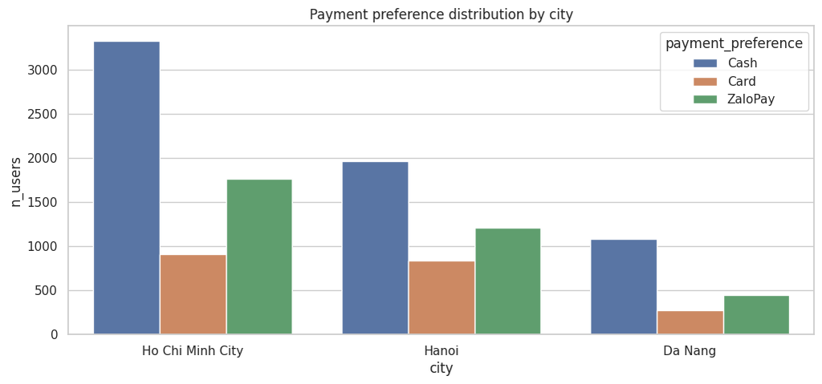

```python
# Payment preference by city
users_pay_city = (
    df_users.groupby(["city", "payment_preference"], observed=False)["user_id"]
    .nunique()
    .reset_index(name="n_users")
)

plt.figure(figsize=(12,5))
sns.barplot(data=users_pay_city, x="city", y="n_users", hue="payment_preference")
plt.title("Payment preference distribution by city")
plt.show()
```

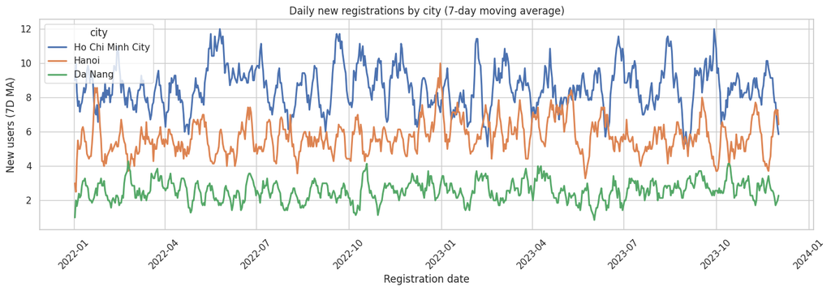

```python
reg_daily = (
    df_users.groupby(["registration_date", "city"], observed=False)["user_id"]
    .nunique()
    .reset_index(name="new_users")
    .sort_values(["city", "registration_date"])
)

reg_daily["new_users_7d_ma"] = (
    reg_daily.groupby("city")["new_users"]
    .transform(lambda s: s.rolling(7, min_periods=1).mean())
)

plt.figure(figsize=(14, 5))
sns.lineplot(
    data=reg_daily,
    x="registration_date",
    y="new_users_7d_ma",
    hue="city",
    linewidth=2
)
plt.title("Daily new registrations by city (7-day moving average)")
plt.xlabel("Registration date")
plt.ylabel("New users (7D MA)")
plt.xticks(rotation=45)
plt.tight_layout()
plt.show()
```

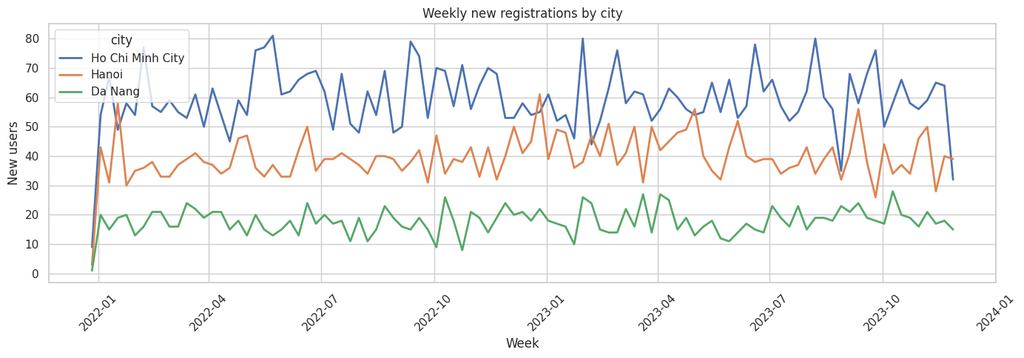

```python
# Registration trend by week
reg_weekly = (
    df_users
    .assign(week_start=df_users["registration_date"] - pd.to_timedelta(df_users["registration_date"].dt.weekday, unit="D"))
    .groupby(["week_start", "city"], observed=False)["user_id"]
    .nunique()
    .reset_index(name="new_users")
)

plt.figure(figsize=(14, 5))
sns.lineplot(
    data=reg_weekly,
    x="week_start",
    y="new_users",
    hue="city",
    linewidth=2
)
plt.title("Weekly new registrations by city")
plt.xlabel("Week")
plt.ylabel("New users")
plt.xticks(rotation=45)
plt.tight_layout()
plt.show()
```

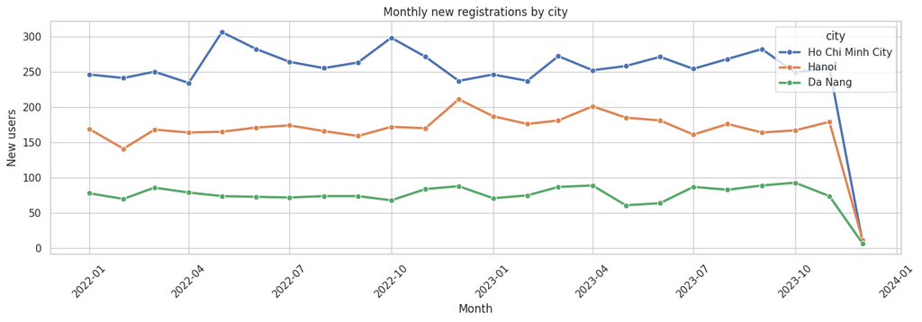

```python
# Registration by week
reg_month = (
    df_users
    .assign(registration_month=df_users["registration_date"].dt.to_period("M").dt.to_timestamp())
    .groupby(["registration_month", "city"], observed=False)["user_id"]
    .nunique()
    .reset_index(name="new_users")
    .sort_values(["registration_month", "city"])
)

plt.figure(figsize=(14, 5))
sns.lineplot(
    data=reg_month,
    x="registration_month",
    y="new_users",
    hue="city",
    linewidth=2.5,
    marker="o"
)

plt.title("Monthly new registrations by city")
plt.xlabel("Month")
plt.ylabel("New users")
plt.xticks(rotation=45)
plt.tight_layout()
plt.show()
```

- **Ho Chi Minh City starts from a much larger base than Hanoi and Da Nang.** It has the largest user population and consistently higher new registrations, which means stronger GMV in HCMC may partly reflect market size rather than the voucher effect alone.
- **Hanoi appears broadly similar to HCMC in customer composition, but smaller in scale.** The segment mix is directionally similar across the two cities, with Regular users forming the largest group, while Cash remains the dominant payment preference in both markets. This makes Hanoi a reasonable candidate for further testing, but not proof that the same uplift will be replicated at the same magnitude.
- **Baseline differences matter for interpreting the pilot result.** Since HCMC already has a larger user base and stronger acquisition trend, a post-pilot GMV increase in HCMC cannot automatically be attributed to the Super-Combo Voucher. The observed uplift may be partly driven by pre-existing market advantages.

### Weather context and rainfall patterns

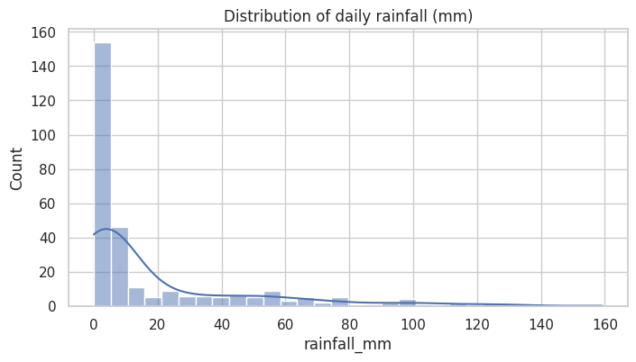

```python
# Rainfall distribution
plt.figure(figsize=(8,4))
sns.histplot(df_weather_daily["rainfall_mm"], bins=30, kde=True)
plt.title("Distribution of daily rainfall (mm)")
plt.show()
```

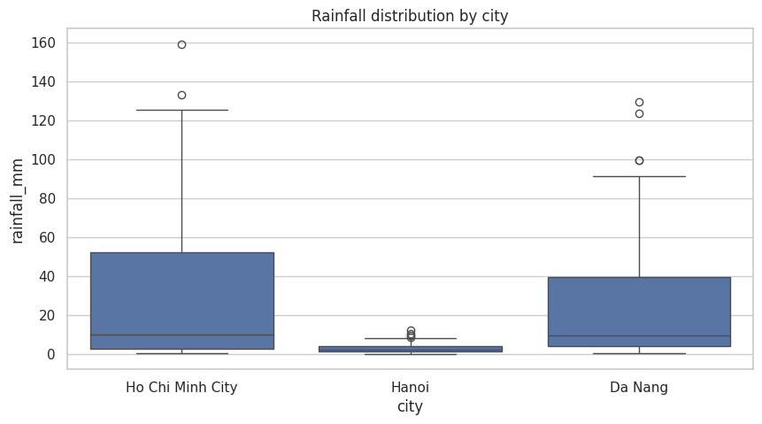

```python
# Rainfall by city
plt.figure(figsize=(10,5))
sns.boxplot(data=df_weather_daily, x="city", y="rainfall_mm")
plt.title("Rainfall distribution by city")
plt.show()
```

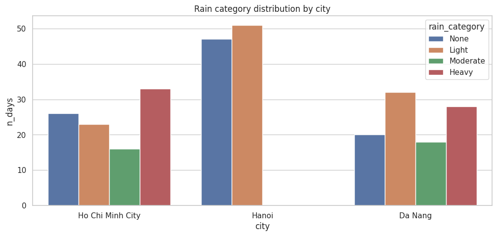

```python
# Rain category distribution by city
rain_cat_city = (
    df_weather_daily.groupby(["city", "rain_category"], observed=False)
    .size()
    .reset_index(name="n_days")
)

plt.figure(figsize=(12,5))
sns.barplot(data=rain_cat_city, x="city", y="n_days", hue="rain_category")
plt.title("Rain category distribution by city")
plt.show()
```

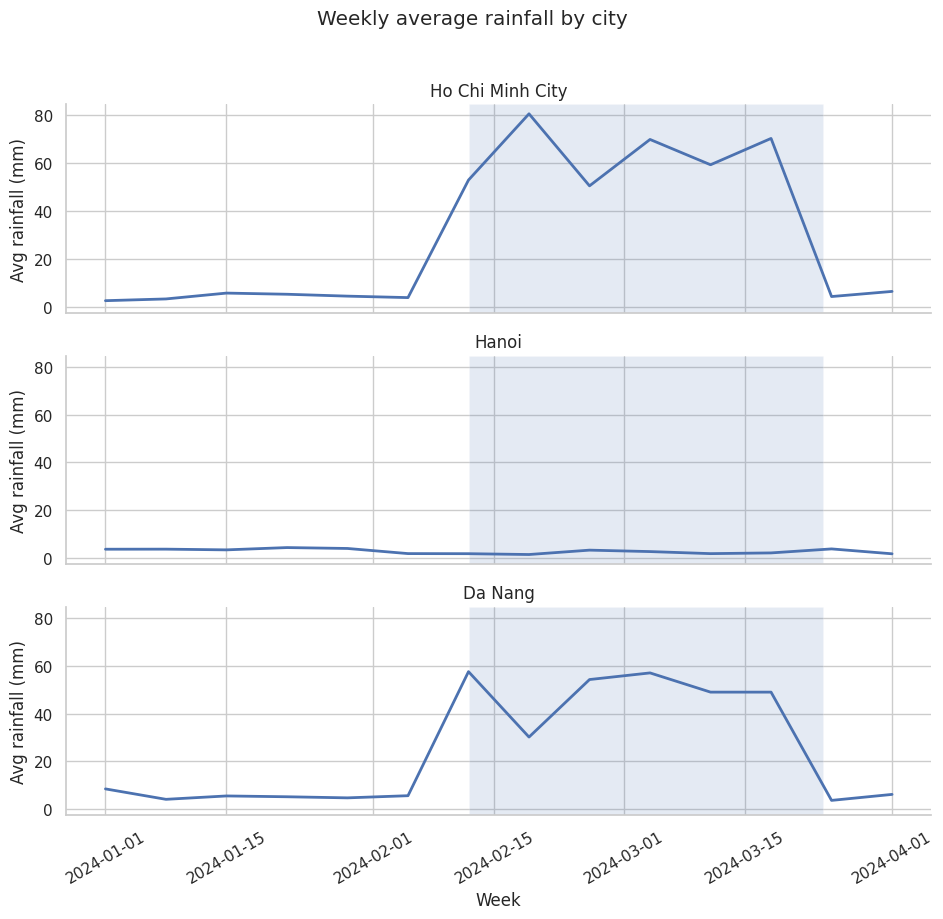

```python
# Weekly average rainfall
df_weather_daily["week_start"] = (
    df_weather_daily["date"] - pd.to_timedelta(df_weather_daily["date"].dt.weekday, unit="D")
)

weather_weekly = (
    df_weather_daily
    .groupby(["week_start", "city"], observed=False)["rainfall_mm"]
    .mean()
    .reset_index(name="avg_rainfall_mm")
    .sort_values(["city", "week_start"])
)

g = sns.relplot(
    data=weather_weekly,
    kind="line",
    x="week_start",
    y="avg_rainfall_mm",
    col="city",
    col_wrap=1,
    height=3,
    aspect=3.2,
    linewidth=2
)

# Promo window: weeks 7–12 = 2024-02-12 to 2024-03-24
promo_start = pd.Timestamp("2024-02-12")
promo_end = pd.Timestamp("2024-03-24")

for ax in g.axes.flatten():
    ax.axvspan(promo_start, promo_end, alpha=0.15)
    ax.tick_params(axis="x", rotation=30)

g.set_titles("{col_name}")
g.set_axis_labels("Week", "Avg rainfall (mm)")
g.fig.suptitle("Weekly average rainfall by city", y=1.02)

plt.tight_layout()
plt.show()
```

## Transaction Sanity Checks

```python
# Uniqueness checks
print("Unique transaction_id:", df_transactions["transaction_id"].nunique())
print("Total rows:", len(df_transactions))
print("Duplicate transaction_id:", df_transactions["transaction_id"].duplicated().sum())
```

```
Unique transaction_id: 182313
Total rows: 182313
Duplicate transaction_id: 0
```

```python
# Basic sanity checks
print("Rows where net > gross:", (df_transactions["net_gmv_k_vnd"] > df_transactions["gross_gmv_k_vnd"]).sum())
print("Rows where discount < 0:", (df_transactions["discount_k_vnd"] < 0).sum())
print("Rows where gross < 0:", (df_transactions["gross_gmv_k_vnd"] < 0).sum())
print("Rows where net < 0:", (df_transactions["net_gmv_k_vnd"] < 0).sum())
```

```
Rows where net > gross: 0
Rows where discount < 0: 0
Rows where gross < 0: 0
Rows where net < 0: 0
```

```python
# Add ratio columns
df_transactions = add_ratio_cols(df_transactions)
display(df_transactions[["gross_gmv_k_vnd", "discount_k_vnd", "net_gmv_k_vnd",
                         "discount_rate", "net_to_gross_ratio"]].describe().T)
```

|  | count | mean | std | min | 25% | 50% | 75% | max |
| --- | --- | --- | --- | --- | --- | --- | --- | --- |
| gross_gmv_k_vnd | 182,313.00 | 120.63 | 63.87 | 28.00 | 42.29 | 131.38 | 172.54 | 225.00 |
| discount_k_vnd | 182,313.00 | 6.43 | 15.00 | 0.00 | 0.00 | 0.00 | 0.00 | 56.24 |
| net_gmv_k_vnd | 182,313.00 | 114.20 | 60.98 | 22.96 | 41.73 | 123.27 | 160.30 | 225.00 |
| discount_rate | 182,313.00 | 0.05 | 0.09 | 0.00 | 0.00 | 0.00 | 0.00 | 0.25 |
| net_to_gross_ratio | 182,313.00 | 0.95 | 0.09 | 0.75 | 1.00 | 1.00 | 1.00 | 1.00 |

## Transaction Overview

### GMV, volume, users, voucher, discount

```python
# Overview by period x city
txn_period_city = (
    df_transactions.groupby(["period", "city"], observed=False)
    .agg(
        n_transactions=("transaction_id", "count"),
        active_users=("user_id", "nunique"),
        gross_gmv_k_vnd=("gross_gmv_k_vnd", "sum"),
        discount_k_vnd=("discount_k_vnd", "sum"),
        net_gmv_k_vnd=("net_gmv_k_vnd", "sum"),
        voucher_txns=("voucher_applied", "sum"),
        avg_rainfall_mm=("rainfall_mm", "mean")
    )
    .reset_index()
)

txn_period_city["txns_per_user"] = txn_period_city["n_transactions"] / txn_period_city["active_users"]
txn_period_city["net_gmv_per_txn"] = txn_period_city["net_gmv_k_vnd"] / txn_period_city["n_transactions"]
txn_period_city["voucher_rate"] = txn_period_city["voucher_txns"] / txn_period_city["n_transactions"]
txn_period_city["discount_rate"] = txn_period_city["discount_k_vnd"] / txn_period_city["gross_gmv_k_vnd"]

display(txn_period_city)
```

|  | period | city | n_transactions | active_users | gross_gmv_k_vnd | discount_k_vnd | net_gmv_k_vnd | voucher_txns | avg_rainfall_mm | txns_per_user | net_gmv_per_txn | voucher_rate | discount_rate |
| --- | --- | --- | --- | --- | --- | --- | --- | --- | --- | --- | --- | --- | --- |
| 0 | Pre-Promo | Ho Chi Minh City | 36149 | 5986 | 4,140,233.94 | 0.00 | 4,140,233.94 | 0 | 4.42 | 6.04 | 114.53 | 0.00 | 0.00 |
| 1 | Pre-Promo | Hanoi | 23610 | 3989 | 2,635,188.37 | 0.00 | 2,635,188.37 | 0 | 3.59 | 5.92 | 111.61 | 0.00 | 0.00 |
| 2 | Pre-Promo | Da Nang | 9951 | 1790 | 1,127,543.48 | 0.00 | 1,127,543.48 | 0 | 5.77 | 5.56 | 113.31 | 0.00 | 0.00 |
| 3 | Promo | Ho Chi Minh City | 54502 | 5999 | 7,386,069.08 | 1,172,951.28 | 6,213,116.44 | 35015 | 65.23 | 9.09 | 114.00 | 0.64 | 0.16 |
| 4 | Promo | Hanoi | 24008 | 3997 | 2,656,926.28 | 0.00 | 2,656,926.28 | 0 | 2.27 | 6.01 | 110.67 | 0.00 | 0.00 |
| 5 | Promo | Da Nang | 12006 | 1798 | 1,557,579.90 | 0.00 | 1,557,579.90 | 0 | 50.51 | 6.68 | 129.73 | 0.00 | 0.00 |
| 6 | Post-Promo | Ho Chi Minh City | 10539 | 4940 | 1,198,175.93 | 0.00 | 1,198,175.93 | 0 | 5.71 | 2.13 | 113.69 | 0.00 | 0.00 |
| 7 | Post-Promo | Hanoi | 8242 | 3503 | 917,570.84 | 0.00 | 917,570.84 | 0 | 2.76 | 2.35 | 111.33 | 0.00 | 0.00 |
| 8 | Post-Promo | Da Nang | 3306 | 1521 | 373,170.04 | 0.00 | 373,170.04 | 0 | 5.12 | 2.17 | 112.88 | 0.00 | 0.00 |

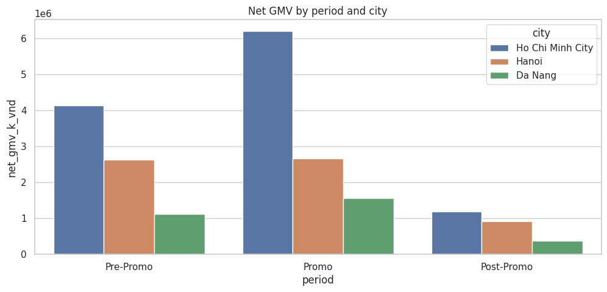

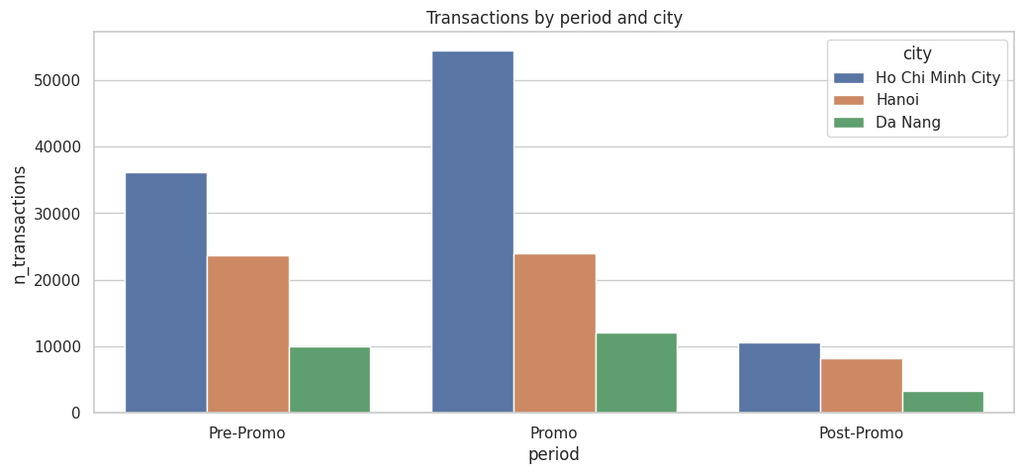

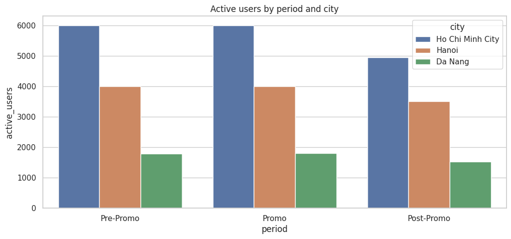

```python
plot_bar(txn_period_city, x="period", y="net_gmv_k_vnd", hue="city",
         title="Net GMV by period and city")

plot_bar(txn_period_city, x="period", y="n_transactions", hue="city",
         title="Transactions by period and city")

plot_bar(txn_period_city, x="period", y="active_users", hue="city",
         title="Active users by period and city")
```

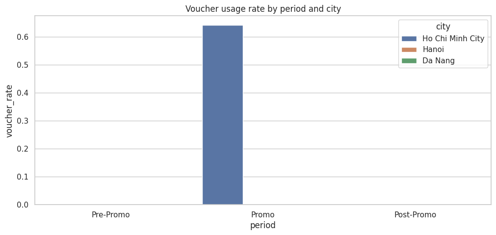

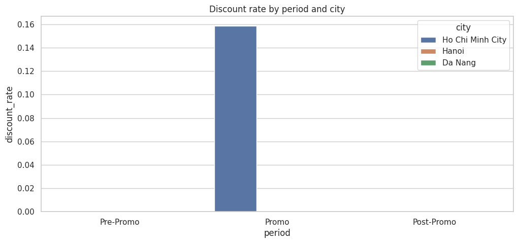

```python
plot_bar(txn_period_city, x="period", y="voucher_rate", hue="city",
         title="Voucher usage rate by period and city")

plot_bar(txn_period_city, x="period", y="discount_rate", hue="city",
         title="Discount rate by period and city")
```

- Voucher usage was exclusive to HCMC during Promo, reaching about 64% of transactions.
- Discounting was also concentrated only in HCMC Promo, with a ~16% discount rate.
- No voucher or discount activity appears in Hanoi or Da Nang, or outside the Promo period.

### Transactions by week

```python
txn_weekly_city = (
    df_transactions.groupby(["week_number", "period", "city"], observed=False)
    .agg(
        n_transactions=("transaction_id", "count"),
        active_users=("user_id", "nunique"),
        gross_gmv_k_vnd=("gross_gmv_k_vnd", "sum"),
        discount_k_vnd=("discount_k_vnd", "sum"),
        net_gmv_k_vnd=("net_gmv_k_vnd", "sum"),
        voucher_txns=("voucher_applied", "sum"),
        avg_rainfall_mm=("rainfall_mm", "mean")
    )
    .reset_index()
)

txn_weekly_city["txns_per_user"] = txn_weekly_city["n_transactions"] / txn_weekly_city["active_users"]
txn_weekly_city["net_gmv_per_txn"] = txn_weekly_city["net_gmv_k_vnd"] / txn_weekly_city["n_transactions"]
txn_weekly_city["voucher_rate"] = txn_weekly_city["voucher_txns"] / txn_weekly_city["n_transactions"]
txn_weekly_city["discount_rate"] = txn_weekly_city["discount_k_vnd"] / txn_weekly_city["gross_gmv_k_vnd"]

display(txn_weekly_city.head())
```

|  | week_number | period | city | n_transactions | active_users | gross_gmv_k_vnd | discount_k_vnd | net_gmv_k_vnd | voucher_txns | avg_rainfall_mm | txns_per_user | net_gmv_per_txn | voucher_rate | discount_rate |
| --- | --- | --- | --- | --- | --- | --- | --- | --- | --- | --- | --- | --- | --- | --- |
| 0 | 1 | Pre-Promo | Ho Chi Minh City | 6008 | 3781 | 679,830.94 | 0.00 | 679,830.94 | 0 | 2.67 | 1.59 | 113.15 | 0.00 | 0.00 |
| 1 | 1 | Pre-Promo | Hanoi | 4016 | 2485 | 448,404.56 | 0.00 | 448,404.56 | 0 | 3.71 | 1.62 | 111.65 | 0.00 | 0.00 |
| 2 | 1 | Pre-Promo | Da Nang | 1678 | 1092 | 193,488.08 | 0.00 | 193,488.08 | 0 | 8.90 | 1.54 | 115.31 | 0.00 | 0.00 |
| 3 | 1 | Promo | Ho Chi Minh City | 0 | 0 | 0.00 | 0.00 | 0.00 | 0 | NaN | NaN | NaN | NaN | NaN |
| 4 | 1 | Promo | Hanoi | 0 | 0 | 0.00 | 0.00 | 0.00 | 0 | NaN | NaN | NaN | NaN | NaN |

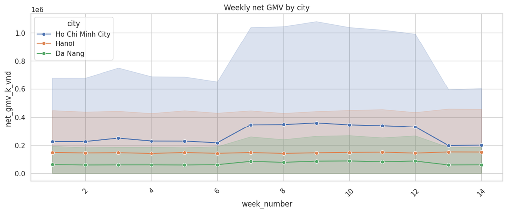

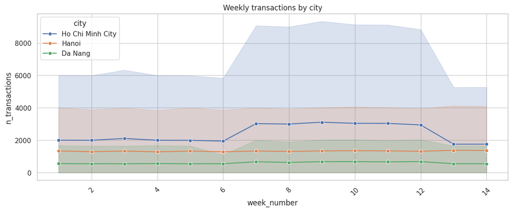

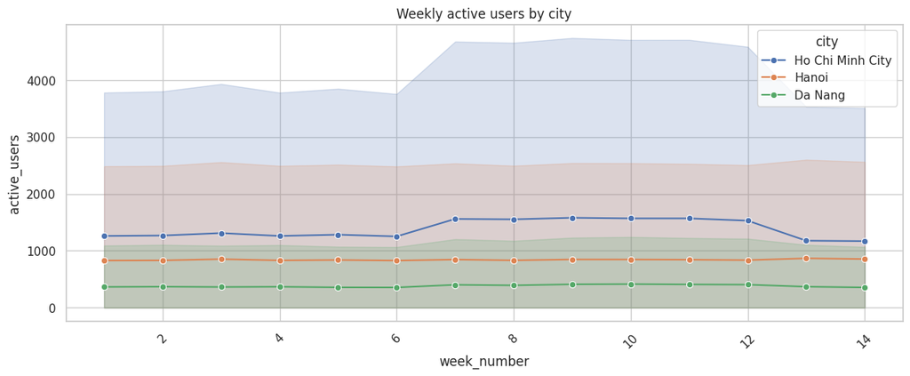

```python
plot_line(txn_weekly_city, x="week_number", y="net_gmv_k_vnd", hue="city",
          title="Weekly net GMV by city")

plot_line(txn_weekly_city, x="week_number", y="n_transactions", hue="city",
          title="Weekly transactions by city")

plot_line(txn_weekly_city, x="week_number", y="active_users", hue="city",
          title="Weekly active users by city")
```

- HCMC shows a clear step-up during Promo across transactions, active users, and net GMV.
- The uplift appears to come from both broader user activity and higher usage frequency.
- Hanoi remains broadly flat, so the HCMC pattern does not look like a market-wide trend.
- Da Nang also improves slightly, which means external factors may still be contributing.
- Post-Promo, HCMC drops back, suggesting the uplift may be temporary rather than fully sustainable.

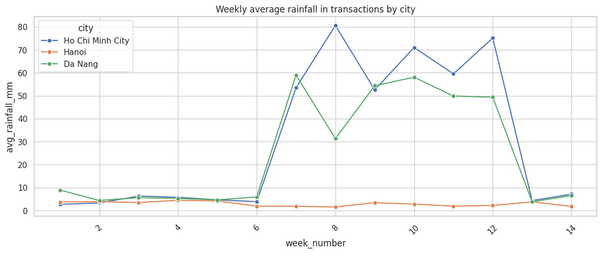

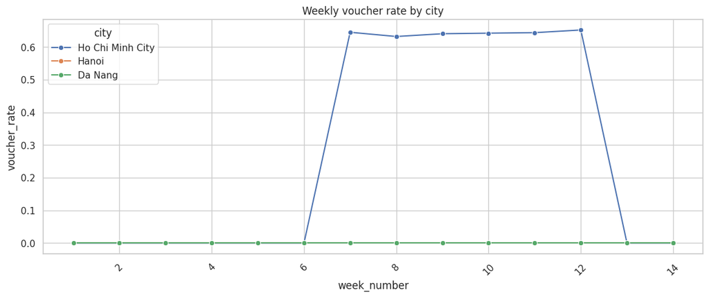

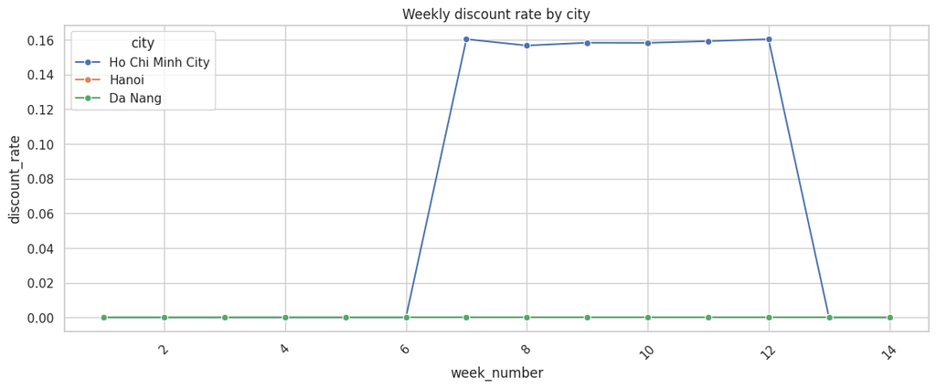

```python
plot_line(txn_weekly_city, x="week_number", y="avg_rainfall_mm", hue="city",
          title="Weekly average rainfall in transactions by city")

plot_line(txn_weekly_city, x="week_number", y="voucher_rate", hue="city",
          title="Weekly voucher rate by city")

plot_line(txn_weekly_city, x="week_number", y="discount_rate", hue="city",
          title="Weekly discount rate by city")
```

- Voucher exposure was exclusive to HCMC during weeks 7–12, confirming a clean pilot setup.
- HCMC Promo also carried a heavy subsidy load, with voucher rate around 64–65% and discount rate around 16%.
- Rainfall spiked sharply in HCMC during the same weeks, with Da Nang showing a similar weather pattern.
- This means the HCMC uplift cannot be attributed to the voucher alone; weather is a meaningful confounder.

### Transactions by service

```python
txn_service = (
    df_transactions.groupby(["period", "city", "service_type"], observed=False)
    .agg(
        n_transactions=("transaction_id", "count"),
        active_users=("user_id", "nunique"),
        gross_gmv_k_vnd=("gross_gmv_k_vnd", "sum"),
        discount_k_vnd=("discount_k_vnd", "sum"),
        net_gmv_k_vnd=("net_gmv_k_vnd", "sum"),
        voucher_txns=("voucher_applied", "sum"),
        avg_rainfall_mm=("rainfall_mm", "mean")
    )
    .reset_index()
)

txn_service["txns_per_user"] = txn_service["n_transactions"] / txn_service["active_users"]
txn_service["net_gmv_per_txn"] = txn_service["net_gmv_k_vnd"] / txn_service["n_transactions"]
txn_service["voucher_rate"] = txn_service["voucher_txns"] / txn_service["n_transactions"]
txn_service["discount_rate"] = txn_service["discount_k_vnd"] / txn_service["gross_gmv_k_vnd"]

display(txn_service.head(30))
```

|  | period | city | service_type | n_transactions | active_users | gross_gmv_k_vnd | discount_k_vnd | net_gmv_k_vnd | voucher_txns | avg_rainfall_mm | txns_per_user | net_gmv_per_txn | voucher_rate | discount_rate |
| --- | --- | --- | --- | --- | --- | --- | --- | --- | --- | --- | --- | --- | --- | --- |
| 0 | Pre-Promo | Ho Chi Minh City | GrabBike | 13218 | 5388 | 489,382.00 | 0.00 | 489,382.00 | 0 | 4.07 | 2.45 | 37.02 | 0.00 | 0.00 |
| 1 | Pre-Promo | Ho Chi Minh City | GrabCar | 3661 | 2735 | 476,365.91 | 0.00 | 476,365.91 | 0 | 4.66 | 1.34 | 130.12 | 0.00 | 0.00 |
| 2 | Pre-Promo | Ho Chi Minh City | GrabFood | 19270 | 5762 | 3,174,486.03 | 0.00 | 3,174,486.03 | 0 | 4.62 | 3.34 | 164.74 | 0.00 | 0.00 |
| 3 | Pre-Promo | Hanoi | GrabBike | 9097 | 3598 | 337,036.71 | 0.00 | 337,036.71 | 0 | 3.55 | 2.53 | 37.05 | 0.00 | 0.00 |
| 4 | Pre-Promo | Hanoi | GrabCar | 2680 | 1963 | 347,691.18 | 0.00 | 347,691.18 | 0 | 3.64 | 1.37 | 129.74 | 0.00 | 0.00 |
| 5 | Pre-Promo | Hanoi | GrabFood | 11833 | 3802 | 1,950,460.48 | 0.00 | 1,950,460.48 | 0 | 3.61 | 3.11 | 164.83 | 0.00 | 0.00 |
| 6 | Pre-Promo | Da Nang | GrabBike | 3756 | 1572 | 139,085.59 | 0.00 | 139,085.59 | 0 | 5.49 | 2.39 | 37.03 | 0.00 | 0.00 |
| 7 | Pre-Promo | Da Nang | GrabCar | 1033 | 785 | 133,815.37 | 0.00 | 133,815.37 | 0 | 6.00 | 1.32 | 129.54 | 0.00 | 0.00 |
| 8 | Pre-Promo | Da Nang | GrabFood | 5162 | 1710 | 854,642.52 | 0.00 | 854,642.52 | 0 | 5.93 | 3.02 | 165.56 | 0.00 | 0.00 |
| 9 | Promo | Ho Chi Minh City | GrabBike | 10843 | 5015 | 400,806.09 | 52,080.99 | 348,725.18 | 7829 | 61.67 | 2.16 | 32.16 | 0.72 | 0.13 |
| 10 | Promo | Ho Chi Minh City | GrabCar | 6172 | 3849 | 801,583.42 | 0.00 | 801,583.42 | 0 | 67.50 | 1.60 | 129.87 | 0.00 | 0.00 |
| 11 | Promo | Ho Chi Minh City | GrabFood | 37487 | 5987 | 6,183,679.57 | 1,120,870.29 | 5,062,807.84 | 27186 | 65.89 | 6.26 | 135.06 | 0.73 | 0.18 |
| 12 | Promo | Hanoi | GrabBike | 9433 | 3611 | 348,973.07 | 0.00 | 348,973.07 | 0 | 2.28 | 2.61 | 36.99 | 0.00 | 0.00 |
| 13 | Promo | Hanoi | GrabCar | 2652 | 1942 | 346,254.89 | 0.00 | 346,254.89 | 0 | 2.22 | 1.37 | 130.56 | 0.00 | 0.00 |
| 14 | Promo | Hanoi | GrabFood | 11923 | 3805 | 1,961,698.32 | 0.00 | 1,961,698.32 | 0 | 2.27 | 3.13 | 164.53 | 0.00 | 0.00 |
| 15 | Promo | Da Nang | GrabBike | 2840 | 1423 | 104,809.33 | 0.00 | 104,809.33 | 0 | 46.98 | 2.00 | 36.90 | 0.00 | 0.00 |
| 16 | Promo | Da Nang | GrabCar | 1734 | 1116 | 225,564.04 | 0.00 | 225,564.04 | 0 | 52.38 | 1.55 | 130.08 | 0.00 | 0.00 |
| 17 | Promo | Da Nang | GrabFood | 7432 | 1767 | 1,227,206.53 | 0.00 | 1,227,206.53 | 0 | 51.42 | 4.21 | 165.12 | 0.00 | 0.00 |
| 18 | Post-Promo | Ho Chi Minh City | GrabBike | 3910 | 2872 | 145,069.21 | 0.00 | 145,069.21 | 0 | 5.27 | 1.36 | 37.10 | 0.00 | 0.00 |
| 19 | Post-Promo | Ho Chi Minh City | GrabCar | 1070 | 974 | 137,767.06 | 0.00 | 137,767.06 | 0 | 6.06 | 1.10 | 128.75 | 0.00 | 0.00 |
| 20 | Post-Promo | Ho Chi Minh City | GrabFood | 5559 | 3631 | 915,339.66 | 0.00 | 915,339.66 | 0 | 5.95 | 1.53 | 164.66 | 0.00 | 0.00 |
| 21 | Post-Promo | Hanoi | GrabBike | 3207 | 2184 | 119,071.33 | 0.00 | 119,071.33 | 0 | 2.78 | 1.47 | 37.13 | 0.00 | 0.00 |
| 22 | Post-Promo | Hanoi | GrabCar | 873 | 782 | 113,463.63 | 0.00 | 113,463.63 | 0 | 2.84 | 1.12 | 129.97 | 0.00 | 0.00 |
| 23 | Post-Promo | Hanoi | GrabFood | 4162 | 2594 | 685,035.88 | 0.00 | 685,035.88 | 0 | 2.72 | 1.60 | 164.59 | 0.00 | 0.00 |
| 24 | Post-Promo | Da Nang | GrabBike | 1252 | 922 | 46,386.90 | 0.00 | 46,386.90 | 0 | 4.75 | 1.36 | 37.05 | 0.00 | 0.00 |
| 25 | Post-Promo | Da Nang | GrabCar | 341 | 315 | 44,222.08 | 0.00 | 44,222.08 | 0 | 5.33 | 1.08 | 129.68 | 0.00 | 0.00 |
| 26 | Post-Promo | Da Nang | GrabFood | 1713 | 1120 | 282,561.06 | 0.00 | 282,561.06 | 0 | 5.35 | 1.53 | 164.95 | 0.00 | 0.00 |

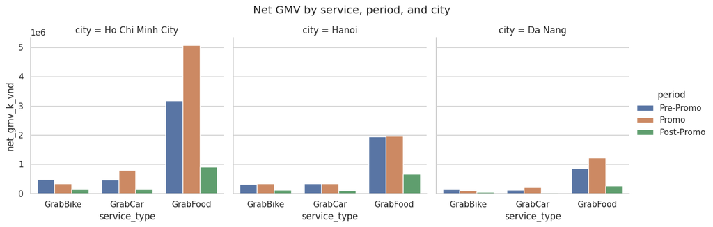

```python
g = sns.catplot(
    data=txn_service,
    kind="bar",
    x="service_type", y="net_gmv_k_vnd",
    hue="period", col="city",
    height=4, aspect=1
)
g.fig.suptitle("Net GMV by service, period, and city", y=1.05)
plt.show()
```

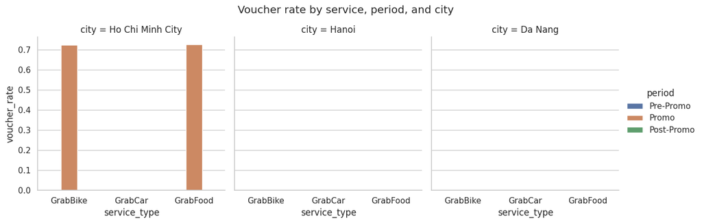

```python
g = sns.catplot(
    data=txn_service,
    kind="bar",
    x="service_type", y="voucher_rate",
    hue="period", col="city",
    height=4, aspect=1
)
g.fig.suptitle("Voucher rate by service, period, and city", y=1.05)
plt.show()
```

Voucher usage was visible only in HCMC during the Promo period, and only for GrabBike and GrabFood, confirming a clean pilot setup.

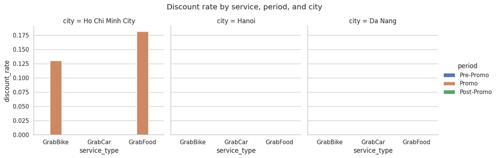

```python
g = sns.catplot(
    data=txn_service,
    kind="bar",
    x="service_type", y="discount_rate",
    hue="period", col="city",
    height=4, aspect=1
)
g.fig.suptitle("Discount rate by service, period, and city", y=1.05)
plt.show()
```

Discounting was concentrated only in HCMC during Promo, with heavier subsidy on GrabFood (18%) than GrabBike (13%), confirming a clean and service-targeted pilot setup.

=> The **service-level breakdown** suggests that **promo-period uplift in HCMC** was concentrated primarily in **GrabFood**, while **mobility services** showed a more limited response. This indicates that the **topline gains** were likely driven by **service mix** rather than by a **uniformly strong combo effect** across the platform.

### Transactions by payment type

```python
txn_payment = (
    df_transactions.groupby(["period", "city", "payment_type"], observed=False)
    .agg(
        n_transactions=("transaction_id", "count"),
        active_users=("user_id", "nunique"),
        gross_gmv_k_vnd=("gross_gmv_k_vnd", "sum"),
        discount_k_vnd=("discount_k_vnd", "sum"),
        net_gmv_k_vnd=("net_gmv_k_vnd", "sum"),
        voucher_txns=("voucher_applied", "sum")
    )
    .reset_index()
)

txn_payment["voucher_rate"] = txn_payment["voucher_txns"] / txn_payment["n_transactions"]
txn_payment["discount_rate"] = txn_payment["discount_k_vnd"] / txn_payment["gross_gmv_k_vnd"]

display(txn_payment.head(20))
```

|  | period | city | payment_type | n_transactions | active_users | gross_gmv_k_vnd | discount_k_vnd | net_gmv_k_vnd | voucher_txns | voucher_rate | discount_rate |
| --- | --- | --- | --- | --- | --- | --- | --- | --- | --- | --- | --- |
| 0 | Pre-Promo | Ho Chi Minh City | Cash | 19996 | 3321 | 2,298,807.71 | 0.00 | 2,298,807.71 | 0 | 0.00 | 0.00 |
| 1 | Pre-Promo | Ho Chi Minh City | Card | 5569 | 903 | 639,196.61 | 0.00 | 639,196.61 | 0 | 0.00 | 0.00 |
| 2 | Pre-Promo | Ho Chi Minh City | ZaloPay | 10584 | 1762 | 1,202,229.62 | 0.00 | 1,202,229.62 | 0 | 0.00 | 0.00 |
| 3 | Pre-Promo | Hanoi | Cash | 11573 | 1954 | 1,292,125.56 | 0.00 | 1,292,125.56 | 0 | 0.00 | 0.00 |
| 4 | Pre-Promo | Hanoi | Card | 4898 | 830 | 549,158.62 | 0.00 | 549,158.62 | 0 | 0.00 | 0.00 |
| 5 | Pre-Promo | Hanoi | ZaloPay | 7139 | 1205 | 793,904.19 | 0.00 | 793,904.19 | 0 | 0.00 | 0.00 |
| 6 | Pre-Promo | Da Nang | Cash | 6102 | 1081 | 693,049.18 | 0.00 | 693,049.18 | 0 | 0.00 | 0.00 |
| 7 | Pre-Promo | Da Nang | Card | 1421 | 270 | 159,760.10 | 0.00 | 159,760.10 | 0 | 0.00 | 0.00 |
| 8 | Pre-Promo | Da Nang | ZaloPay | 2428 | 439 | 274,734.20 | 0.00 | 274,734.20 | 0 | 0.00 | 0.00 |
| 9 | Promo | Ho Chi Minh City | Cash | 35226 | 5981 | 4,789,990.22 | 865,383.29 | 3,924,606.34 | 25718 | 0.73 | 0.18 |
| 10 | Promo | Ho Chi Minh City | Card | 6558 | 3985 | 882,339.34 | 105,755.24 | 776,584.65 | 3181 | 0.49 | 0.12 |
| 11 | Promo | Ho Chi Minh City | ZaloPay | 12718 | 5240 | 1,713,739.52 | 201,812.75 | 1,511,925.45 | 6116 | 0.48 | 0.12 |
| 12 | Promo | Hanoi | Cash | 11815 | 1956 | 1,298,120.89 | 0.00 | 1,298,120.89 | 0 | 0.00 | 0.00 |
| 13 | Promo | Hanoi | Card | 4909 | 832 | 547,575.82 | 0.00 | 547,575.82 | 0 | 0.00 | 0.00 |
| 14 | Promo | Hanoi | ZaloPay | 7284 | 1209 | 811,229.57 | 0.00 | 811,229.57 | 0 | 0.00 | 0.00 |
| 15 | Promo | Da Nang | Cash | 7190 | 1083 | 936,576.46 | 0.00 | 936,576.46 | 0 | 0.00 | 0.00 |
| 16 | Promo | Da Nang | Card | 1851 | 273 | 235,596.43 | 0.00 | 235,596.43 | 0 | 0.00 | 0.00 |
| 17 | Promo | Da Nang | ZaloPay | 2965 | 442 | 385,407.01 | 0.00 | 385,407.01 | 0 | 0.00 | 0.00 |
| 18 | Post-Promo | Ho Chi Minh City | Cash | 5468 | 3605 | 620,892.87 | 0.00 | 620,892.87 | 0 | 0.00 | 0.00 |
| 19 | Post-Promo | Ho Chi Minh City | Card | 1873 | 1606 | 214,797.44 | 0.00 | 214,797.44 | 0 | 0.00 | 0.00 |

- By payment type, the Promo effect in HCMC was broad but still cash-led, suggesting the campaign boosted demand more than it changed payment behavior.

[figure not shown]

```python
g = sns.catplot(
    data=txn_payment,
    kind="bar",
    x="payment_type", y="net_gmv_k_vnd",
    hue="period", col="city",
    height=4, aspect=1
)
g.fig.suptitle("Net GMV by payment type, period, and city", y=1.05)
plt.show()
```

- **HCMC’s Promo uplift was broad but mainly cash-led** — net GMV increased across Cash, Card, and ZaloPay, but the largest contribution came from **Cash**, showing the pilot boosted overall demand more than it shifted users toward digital payments.

[figure not shown]

```python
g = sns.catplot(
    data=txn_payment,
    kind="bar",
    x="payment_type", y="voucher_rate",
    hue="period", col="city",
    height=4, aspect=1
)
g.fig.suptitle("Voucher rate by payment type, period, and city", y=1.05)
plt.show()
```

- **The voucher was used only in HCMC during Promo and was most heavily adopted by Cash users** — this confirms a clean pilot setup, but also shows the strongest response came from the **cash cohort**, not from a structural move to Card or ZaloPay.

# Diagnostic Analysis

## Merge Transactions with User Data

```python
df_txn_user = df_transactions.merge(
    df_users,
    on="user_id",
    how="left",
    suffixes=("", "_user")
)

# Quick join quality checks
print("Joined table shape:", df_txn_user.shape)
print("Original transactions shape:", df_transactions.shape)

# Count transactions that did not match a user record
unmatched_user_rows = df_txn_user["registration_date"].isna().sum()
print("Transactions with no matched user info:", unmatched_user_rows)
```

```
Joined table shape: (182313, 19)
Original transactions shape: (182313, 15)
Transactions with no matched user info: 0
```

```python
display(df_txn_user.head())
```

|  | transaction_id | date | week_number | period | city | service_type | user_id | payment_type | gross_gmv_k_vnd | discount_k_vnd | net_gmv_k_vnd | voucher_applied | rainfall_mm | discount_rate | net_to_gross_ratio | city_user | payment_preference | user_segment | registration_date |
| --- | --- | --- | --- | --- | --- | --- | --- | --- | --- | --- | --- | --- | --- | --- | --- | --- | --- | --- | --- |
| 0 | 1 | 2024-01-01 | 1 | Pre-Promo | Ho Chi Minh City | GrabBike | 2883 | Card | 35.53 | 0.00 | 35.53 | 0 | 1.60 | 0.00 | 1.00 | Ho Chi Minh City | Card | High Value | 2023-02-08 |
| 1 | 2 | 2024-01-01 | 1 | Pre-Promo | Ho Chi Minh City | GrabBike | 5904 | Cash | 36.74 | 0.00 | 36.74 | 0 | 1.60 | 0.00 | 1.00 | Ho Chi Minh City | Cash | Occasional | 2023-03-02 |
| 2 | 3 | 2024-01-01 | 1 | Pre-Promo | Ho Chi Minh City | GrabBike | 1193 | Cash | 44.65 | 0.00 | 44.65 | 0 | 1.60 | 0.00 | 1.00 | Ho Chi Minh City | Cash | Voucher Hunter | 2023-07-29 |
| 3 | 4 | 2024-01-01 | 1 | Pre-Promo | Ho Chi Minh City | GrabBike | 3622 | ZaloPay | 38.32 | 0.00 | 38.32 | 0 | 1.60 | 0.00 | 1.00 | Ho Chi Minh City | ZaloPay | Regular | 2022-07-16 |
| 4 | 5 | 2024-01-01 | 1 | Pre-Promo | Ho Chi Minh City | GrabBike | 5869 | Cash | 28.52 | 0.00 | 28.52 | 0 | 1.60 | 0.00 | 1.00 | Ho Chi Minh City | Cash | Regular | 2023-10-10 |

```python
txn_segment = (
    df_txn_user.groupby(["period", "city", "user_segment"], observed=False)
    .agg(
        n_transactions=("transaction_id", "count"),
        active_users=("user_id", "nunique"),
        gross_gmv_k_vnd=("gross_gmv_k_vnd", "sum"),
        discount_k_vnd=("discount_k_vnd", "sum"),
        net_gmv_k_vnd=("net_gmv_k_vnd", "sum"),
        voucher_txns=("voucher_applied", "sum")
    )
    .reset_index()
)

txn_segment["txns_per_user"] = txn_segment["n_transactions"] / txn_segment["active_users"]
txn_segment["net_gmv_per_txn"] = txn_segment["net_gmv_k_vnd"] / txn_segment["n_transactions"]
txn_segment["voucher_rate"] = txn_segment["voucher_txns"] / txn_segment["n_transactions"]
txn_segment["discount_rate"] = txn_segment["discount_k_vnd"] / txn_segment["gross_gmv_k_vnd"]

display(txn_segment.head())
```

|  | period | city | user_segment | n_transactions | active_users | gross_gmv_k_vnd | discount_k_vnd | net_gmv_k_vnd | voucher_txns | txns_per_user | net_gmv_per_txn | voucher_rate | discount_rate |
| --- | --- | --- | --- | --- | --- | --- | --- | --- | --- | --- | --- | --- | --- |
| 0 | Pre-Promo | Ho Chi Minh City | Voucher Hunter | 9135 | 1510 | 1,041,026.68 | 0.00 | 1,041,026.68 | 0 | 6.05 | 113.96 | 0.00 | 0.00 |
| 1 | Pre-Promo | Ho Chi Minh City | Occasional | 9667 | 1599 | 1,115,330.47 | 0.00 | 1,115,330.47 | 0 | 6.05 | 115.38 | 0.00 | 0.00 |
| 2 | Pre-Promo | Ho Chi Minh City | Regular | 11584 | 1925 | 1,321,964.82 | 0.00 | 1,321,964.82 | 0 | 6.02 | 114.12 | 0.00 | 0.00 |
| 3 | Pre-Promo | Ho Chi Minh City | High Value | 5763 | 952 | 661,911.97 | 0.00 | 661,911.97 | 0 | 6.05 | 114.86 | 0.00 | 0.00 |
| 4 | Pre-Promo | Hanoi | Voucher Hunter | 5371 | 900 | 605,028.52 | 0.00 | 605,028.52 | 0 | 5.97 | 112.65 | 0.00 | 0.00 |

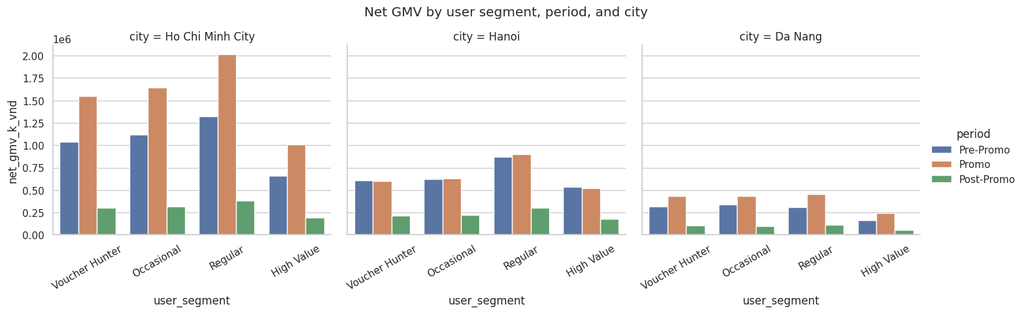

```python
g = sns.catplot(
    data=txn_segment,
    kind="bar",
    x="user_segment", y="net_gmv_k_vnd",
    hue="period", col="city",
    height=4, aspect=1.2
)
g.set_xticklabels(rotation=30)
g.fig.suptitle("Net GMV by user segment, period, and city", y=1.05)
plt.show()
```

- The HCMC Promo uplift was broad-based across user segments, but it was led primarily by Regular users, who remained the largest and most important GMV contributor.

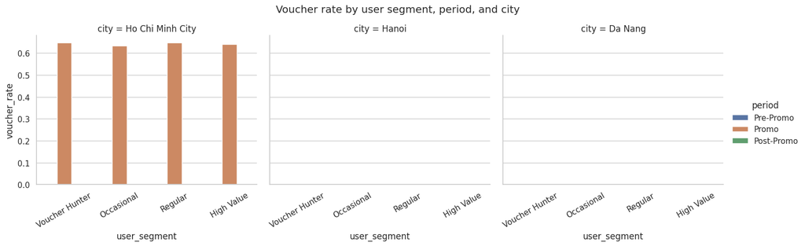

```python
g = sns.catplot(
    data=txn_segment,
    kind="bar",
    x="user_segment", y="voucher_rate",
    hue="period", col="city",
    height=4, aspect=1.2
)
g.set_xticklabels(rotation=30)
g.fig.suptitle("Voucher rate by user segment, period, and city", y=1.05)
plt.show()
```

- Voucher adoption in HCMC Promo was high and broadly consistent across all user segments, showing the pilot reached the full user base rather than only a narrow voucher-seeking cohort.

## Merge Transactions with Weather

```python
df_txn_weather = df_transactions.merge(
    df_weather_daily[["date", "city", "rain_category", "rainfall_mm"]],
    on=["date", "city", "rainfall_mm"],
    how="left"
)

print(df_txn_weather.shape)
print("Missing rain_category after join:", df_txn_weather["rain_category"].isna().sum())
```

```
(182313, 16)
Missing rain_category after join: 0
```

```python
display(df_txn_weather.head())
```

|  | transaction_id | date | week_number | period | city | service_type | user_id | payment_type | gross_gmv_k_vnd | discount_k_vnd | net_gmv_k_vnd | voucher_applied | rainfall_mm | discount_rate | net_to_gross_ratio | rain_category |
| --- | --- | --- | --- | --- | --- | --- | --- | --- | --- | --- | --- | --- | --- | --- | --- | --- |
| 0 | 1 | 2024-01-01 | 1 | Pre-Promo | Ho Chi Minh City | GrabBike | 2883 | Card | 35.53 | 0.00 | 35.53 | 0 | 1.60 | 0.00 | 1.00 | None |
| 1 | 2 | 2024-01-01 | 1 | Pre-Promo | Ho Chi Minh City | GrabBike | 5904 | Cash | 36.74 | 0.00 | 36.74 | 0 | 1.60 | 0.00 | 1.00 | None |
| 2 | 3 | 2024-01-01 | 1 | Pre-Promo | Ho Chi Minh City | GrabBike | 1193 | Cash | 44.65 | 0.00 | 44.65 | 0 | 1.60 | 0.00 | 1.00 | None |
| 3 | 4 | 2024-01-01 | 1 | Pre-Promo | Ho Chi Minh City | GrabBike | 3622 | ZaloPay | 38.32 | 0.00 | 38.32 | 0 | 1.60 | 0.00 | 1.00 | None |
| 4 | 5 | 2024-01-01 | 1 | Pre-Promo | Ho Chi Minh City | GrabBike | 5869 | Cash | 28.52 | 0.00 | 28.52 | 0 | 1.60 | 0.00 | 1.00 | None |

```python
txn_rain = (
    df_txn_weather.groupby(["city", "period", "rain_category", "service_type"], observed=False)
    .agg(
        n_transactions=("transaction_id", "count"),
        active_users=("user_id", "nunique"),
        gross_gmv_k_vnd=("gross_gmv_k_vnd", "sum"),
        discount_k_vnd=("discount_k_vnd", "sum"),
        net_gmv_k_vnd=("net_gmv_k_vnd", "sum"),
        voucher_txns=("voucher_applied", "sum")
    )
    .reset_index()
)

txn_rain["voucher_rate"] = txn_rain["voucher_txns"] / txn_rain["n_transactions"]
txn_rain["discount_rate"] = txn_rain["discount_k_vnd"] / txn_rain["gross_gmv_k_vnd"]
txn_rain["net_gmv_per_txn"] = txn_rain["net_gmv_k_vnd"] / txn_rain["n_transactions"]

display(txn_rain.head())
```

|  | city | period | rain_category | service_type | n_transactions | active_users | gross_gmv_k_vnd | discount_k_vnd | net_gmv_k_vnd | voucher_txns | voucher_rate | discount_rate | net_gmv_per_txn |
| --- | --- | --- | --- | --- | --- | --- | --- | --- | --- | --- | --- | --- | --- |
| 0 | Ho Chi Minh City | Pre-Promo | None | GrabBike | 6783 | 4055 | 251,186.73 | 0.00 | 251,186.73 | 0 | 0.00 | 0.00 | 37.03 |
| 1 | Ho Chi Minh City | Pre-Promo | None | GrabCar | 1738 | 1506 | 225,947.83 | 0.00 | 225,947.83 | 0 | 0.00 | 0.00 | 130.00 |
| 2 | Ho Chi Minh City | Pre-Promo | None | GrabFood | 9245 | 4715 | 1,522,070.97 | 0.00 | 1,522,070.97 | 0 | 0.00 | 0.00 | 164.64 |
| 3 | Ho Chi Minh City | Pre-Promo | Light | GrabBike | 5029 | 3424 | 185,798.21 | 0.00 | 185,798.21 | 0 | 0.00 | 0.00 | 36.95 |
| 4 | Ho Chi Minh City | Pre-Promo | Light | GrabCar | 1343 | 1195 | 174,941.82 | 0.00 | 174,941.82 | 0 | 0.00 | 0.00 | 130.26 |

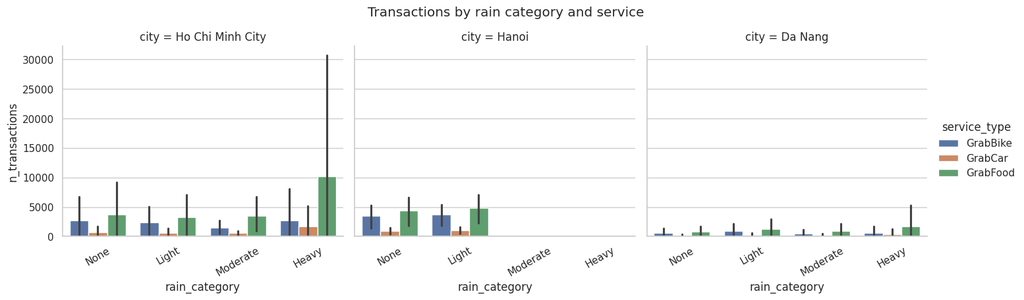

```python
g = sns.catplot(
    data=txn_rain,
    kind="bar",
    x="rain_category", y="n_transactions",
    hue="service_type", col="city",
    height=4, aspect=1.2
)
g.set_xticklabels(rotation=30)
g.fig.suptitle("Transactions by rain category and service", y=1.05)
plt.show()
```

- Rain appears to lift demand mainly through GrabFood—especially in HCMC—while Hanoi shows a weaker pattern and Da Nang shows a smaller but similar direction, so higher transaction volume during Promo may be partly weather-driven, not voucher-driven alone.

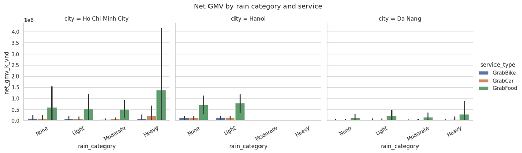

```python
g = sns.catplot(
    data=txn_rain,
    kind="bar",
    x="rain_category", y="net_gmv_k_vnd",
    hue="service_type", col="city",
    height=4, aspect=1.2
)
g.set_xticklabels(rotation=30)
g.fig.suptitle("Net GMV by rain category and service", y=1.05)
plt.show()
```

- Net GMV also rises most clearly for GrabFood under heavier rain, particularly in HCMC, which means part of the HCMC GMV uplift may reflect rain-supported delivery demand rather than pure voucher impact.